[figure not shown]

# Análise Exploratória de Dados com R

A base de dados a ser trabalhada contêm nome, cargo e remuneração dos funcionários da cidade de São Francisco em uma base anual de 2011 a 2014. A base de dados está disponível na plataforma Kaggle: https://www.kaggle.com/kaggle/sf-salaries

## Primeiros passos

```r
#Instalar e carregar bibliotecas
#install.packages("patchwork")
#install.packages("psych")
#install.packages("tidyverse")

library(tidyverse)
library(psych)
library(patchwork)
```

#### Comentários:

```r
#Importar dataset e visualizá-lo
dados = read.csv("Salaries.csv")
```

```r
#Visualizar a base de dados
#View(dados)
head(dados)
tail(dados)
```

A data.frame: 6 × 13

|  | Id <int> | EmployeeName <chr> | JobTitle <chr> | BasePay <chr> | OvertimePay <chr> | OtherPay <chr> | Benefits <chr> | TotalPay <dbl> | TotalPayBenefits <dbl> | Year <int> | Notes <lgl> | Agency <chr> | Status <chr> |
| --- | --- | --- | --- | --- | --- | --- | --- | --- | --- | --- | --- | --- | --- |
| 1 | 1 | NATHANIEL FORD | GENERAL MANAGER-METROPOLITAN TRANSIT AUTHORITY | 167411.18 | 0.0 | 400184.25 |  | 567595.4 | 567595.4 | 2011 | NA | San Francisco |  |
| 2 | 2 | GARY JIMENEZ | CAPTAIN III (POLICE DEPARTMENT) | 155966.02 | 245131.88 | 137811.38 |  | 538909.3 | 538909.3 | 2011 | NA | San Francisco |  |
| 3 | 3 | ALBERT PARDINI | CAPTAIN III (POLICE DEPARTMENT) | 212739.13 | 106088.18 | 16452.6 |  | 335279.9 | 335279.9 | 2011 | NA | San Francisco |  |
| 4 | 4 | CHRISTOPHER CHONG | WIRE ROPE CABLE MAINTENANCE MECHANIC | 77916.0 | 56120.71 | 198306.9 |  | 332343.6 | 332343.6 | 2011 | NA | San Francisco |  |
| 5 | 5 | PATRICK GARDNER | DEPUTY CHIEF OF DEPARTMENT,(FIRE DEPARTMENT) | 134401.6 | 9737.0 | 182234.59 |  | 326373.2 | 326373.2 | 2011 | NA | San Francisco |  |
| 6 | 6 | DAVID SULLIVAN | ASSISTANT DEPUTY CHIEF II | 118602.0 | 8601.0 | 189082.74 |  | 316285.7 | 316285.7 | 2011 | NA | San Francisco |  |

A data.frame: 6 × 13

|  | Id <int> | EmployeeName <chr> | JobTitle <chr> | BasePay <chr> | OvertimePay <chr> | OtherPay <chr> | Benefits <chr> | TotalPay <dbl> | TotalPayBenefits <dbl> | Year <int> | Notes <lgl> | Agency <chr> | Status <chr> |
| --- | --- | --- | --- | --- | --- | --- | --- | --- | --- | --- | --- | --- | --- |
| 148649 | 148649 | Leon Walker | Custodian | 0.00 | 0.00 | 0.00 | 0.00 | 0.00 | 0.00 | 2014 | NA | San Francisco | PT |
| 148650 | 148650 | Roy I Tillery | Custodian | 0.00 | 0.00 | 0.00 | 0.00 | 0.00 | 0.00 | 2014 | NA | San Francisco | PT |
| 148651 | 148651 | Not provided | Not provided | Not Provided | Not Provided | Not Provided | Not Provided | 0.00 | 0.00 | 2014 | NA | San Francisco |  |
| 148652 | 148652 | Not provided | Not provided | Not Provided | Not Provided | Not Provided | Not Provided | 0.00 | 0.00 | 2014 | NA | San Francisco |  |
| 148653 | 148653 | Not provided | Not provided | Not Provided | Not Provided | Not Provided | Not Provided | 0.00 | 0.00 | 2014 | NA | San Francisco |  |
| 148654 | 148654 | Joe Lopez | Counselor, Log Cabin Ranch | 0.00 | 0.00 | -618.13 | 0.00 | -618.13 | -618.13 | 2014 | NA | San Francisco | PT |

```r
#Informações da base de dados
glimpse(dados)
```

```
Rows: 148,654
Columns: 13
$ Id               <int> 1, 2, 3, 4, 5, 6, 7, 8, 9, 10, 11, 12, 13, 14, 15, 16…
$ EmployeeName     <chr> "NATHANIEL FORD", "GARY JIMENEZ", "ALBERT PARDINI", "…
$ JobTitle         <chr> "GENERAL MANAGER-METROPOLITAN TRANSIT AUTHORITY", "CA…
$ BasePay          <chr> "167411.18", "155966.02", "212739.13", "77916.0", "13…
$ OvertimePay      <chr> "0.0", "245131.88", "106088.18", "56120.71", "9737.0"…
$ OtherPay         <chr> "400184.25", "137811.38", "16452.6", "198306.9", "182…
$ Benefits         <chr> "", "", "", "", "", "", "", "", "", "", "", "", "", "…
$ TotalPay         <dbl> 567595.4, 538909.3, 335279.9, 332343.6, 326373.2, 316…
$ TotalPayBenefits <dbl> 567595.4, 538909.3, 335279.9, 332343.6, 326373.2, 316…
$ Year             <int> 2011, 2011, 2011, 2011, 2011, 2011, 2011, 2011, 2011,…
$ Notes            <lgl> NA, NA, NA, NA, NA, NA, NA, NA, NA, NA, NA, NA, NA, N…
$ Agency           <chr> "San Francisco", "San Francisco", "San Francisco", "S…
$ Status           <chr> "", "", "", "", "", "", "", "", "", "", "", "", "", "…
```

#### Quadro com as variáveis da base de dados:

| Variável | Significado |
| --- | --- |
| Id | Identificação |
| EmployeeName | Nome do funcionário |
| JobTitle | Cargo |
| BasePay | Salário Base |
| OvertimePay | Pagamento de Hora Extra |
| OtherPay | Outros Pagamentos |
| Benefits | Benefícios |
| TotalPay | Salário Total |
| TotalPayBenefits | Pagamento Total |
| Year | Ano |
| Notes | Notas |
| Agency | Local de Atuação |
| Status | Status |

#### Comentários

- Note que as colunas **BasePay**, **OvertimePay**, **OtherPay**, **Benefits** estão como *string(\<chr>)*, devemos então transformá-las em variaveis numéricas.
- Não é necessário (como feito em python) transformar as colunas **EmployeeName** e **JobTitle** para o tipo adequado para a análise.
- Transformamos as variáveis Id e Year para o tipo *string*.
- Todos os registros da variável **Notes** são nulos - e identificados por *NaN (Not a Number)* - por isso excluiremos a coluna. Todas os valores da variável **Agency** são *Sao Francisco*, portanto, também excluiremos a variável **Agency**. Os registros da variável **Status** não serão úteis para a análise, visto que mais de 74% dos registros são *NaN*. A variável será excluída.

```r
#Valores únicos das variáveis
head(unique(dados$BasePay))
head(unique(dados$OvertimePay))
head(unique(dados$OtherPay))
head(unique(dados$Benefits))
```

1. '167411.18'

2. '155966.02'

3. '212739.13'

4. '77916.0'

5. '134401.6'

6. '118602.0'

1. '0.0'

2. '245131.88'

3. '106088.18'

4. '56120.71'

5. '9737.0'

6. '8601.0'

1. '400184.25'

2. '137811.38'

3. '16452.6'

4. '198306.9'

5. '182234.59'

6. '189082.74'

1. ''

2. '44430.12'

3. '69810.19'

4. '53102.29'

5. '72047.88'

6. '44438.25'

```r
#Transformar as variáveis BasePay, OvertimePay, OtherPay e Benefits em tipos adequados.
attach(dados) # anexando o dataframe dados
dados$BasePay = as.numeric(BasePay)
dados$OvertimePay = as.numeric(OvertimePay)
dados$OtherPay = as.numeric(OtherPay)
dados$Benefits = as.numeric(Benefits)

#Transformar as variáveis Id e Year em tipos adequados.
dados$Id = as.character(Id)
dados$Year = as.character(Year)
# detach(dados) # desanexando o dataframe dados

#Checando as mudanças de tipo:
glimpse(dados)
```

```
Rows: 148,654
Columns: 13
$ Id               <chr> "1", "2", "3", "4", "5", "6", "7", "8", "9", "10", "1…
$ EmployeeName     <chr> "NATHANIEL FORD", "GARY JIMENEZ", "ALBERT PARDINI", "…
$ JobTitle         <chr> "GENERAL MANAGER-METROPOLITAN TRANSIT AUTHORITY", "CA…
$ BasePay          <dbl> 167411.18, 155966.02, 212739.13, 77916.00, 134401.60,…
$ OvertimePay      <dbl> 0.00, 245131.88, 106088.18, 56120.71, 9737.00, 8601.0…
$ OtherPay         <dbl> 400184.25, 137811.38, 16452.60, 198306.90, 182234.59,…
$ Benefits         <dbl> NA, NA, NA, NA, NA, NA, NA, NA, NA, NA, NA, NA, NA, N…
$ TotalPay         <dbl> 567595.4, 538909.3, 335279.9, 332343.6, 326373.2, 316…
$ TotalPayBenefits <dbl> 567595.4, 538909.3, 335279.9, 332343.6, 326373.2, 316…
$ Year             <chr> "2011", "2011", "2011", "2011", "2011", "2011", "2011…
$ Notes            <lgl> NA, NA, NA, NA, NA, NA, NA, NA, NA, NA, NA, NA, NA, N…
$ Agency           <chr> "San Francisco", "San Francisco", "San Francisco", "S…
$ Status           <chr> "", "", "", "", "", "", "", "", "", "", "", "", "", "…
```

```r
#Variáveis Notes, Agency e Status
head(subset(dados, select = c(Id, Notes, Agency, Status)), 5)
tail(subset(dados, select = c(Id, Notes, Agency, Status)), 5)

dados$Status = na_if(dados$Status,"")
```

A data.frame: 5 × 4

|  | Id <chr> | Notes <lgl> | Agency <chr> | Status <chr> |
| --- | --- | --- | --- | --- |
| 1 | 1 | NA | San Francisco |  |
| 2 | 2 | NA | San Francisco |  |
| 3 | 3 | NA | San Francisco |  |
| 4 | 4 | NA | San Francisco |  |
| 5 | 5 | NA | San Francisco |  |

A data.frame: 5 × 4

|  | Id <chr> | Notes <lgl> | Agency <chr> | Status <chr> |
| --- | --- | --- | --- | --- |
| 148650 | 148650 | NA | San Francisco | PT |
| 148651 | 148651 | NA | San Francisco |  |
| 148652 | 148652 | NA | San Francisco |  |
| 148653 | 148653 | NA | San Francisco |  |
| 148654 | 148654 | NA | San Francisco | PT |

#### Comentários:

- Abaixo, podemos verificar a quantidade de registros *NaN (Not a Number)* para as variáveis **Notes** e **Status**. Podendo, assim, observar uma significativa quantidade de registros indisponíveis. Também podemos observar a frequência de registros da variável **Agency**, observando que esta apresenta o mesmo registro (*San Francisco*) ao longo de toda a base de dados. Dessa forma, iremos excluir essas variáveis a fim de retirar informações que não nos serão úteis.
- Utilizaremos a função *select* para excluir essas três variáveis do *data frame* dados.

```r
#Verificando variáveis Notes, Agency e Status
cat("Quantidade e porcentagem de registros 'NaN' ou 'na':",
    "\n Agency: ", sum(is.na(Agency)), "-", 100*sum(is.na(Agency))/nrow(dados),"%",
    "\n Notes: ", sum(is.na(Notes)), "-", 100*sum(is.na(Notes))/nrow(dados),"%",
    "\n Status: ", sum(is.na(dados$Status)), "-", 100*sum(is.na(dados$Status))/nrow(dados),"%")
table(Agency)
```

```
Quantidade e porcentagem de registros 'NaN' ou 'na':
 Agency:  0 - 0 %
 Notes:  148654 - 100 %
 Status:  110535 - 74.35723 %
```

```
Agency
San Francisco
       148654
```

```r
#Excluir variáveis Agency, Notes e Status
dados <- dados %>%
  select(-c(Agency,Notes,Status))

glimpse(dados)
```

```
Rows: 148,654
Columns: 10
$ Id               <chr> "1", "2", "3", "4", "5", "6", "7", "8", "9", "10", "1…
$ EmployeeName     <chr> "NATHANIEL FORD", "GARY JIMENEZ", "ALBERT PARDINI", "…
$ JobTitle         <chr> "GENERAL MANAGER-METROPOLITAN TRANSIT AUTHORITY", "CA…
$ BasePay          <dbl> 167411.18, 155966.02, 212739.13, 77916.00, 134401.60,…
$ OvertimePay      <dbl> 0.00, 245131.88, 106088.18, 56120.71, 9737.00, 8601.0…
$ OtherPay         <dbl> 400184.25, 137811.38, 16452.60, 198306.90, 182234.59,…
$ Benefits         <dbl> NA, NA, NA, NA, NA, NA, NA, NA, NA, NA, NA, NA, NA, N…
$ TotalPay         <dbl> 567595.4, 538909.3, 335279.9, 332343.6, 326373.2, 316…
$ TotalPayBenefits <dbl> 567595.4, 538909.3, 335279.9, 332343.6, 326373.2, 316…
$ Year             <chr> "2011", "2011", "2011", "2011", "2011", "2011", "2011…
```

## Padronizando os dados da variável JobTitle

#### Variável JobTitle

```r
# Verificando a frequência para a variável JobTitle
dados %>%
  count(JobTitle, sort=T) %>%
  top_n(20)
```

A data.frame: 20 × 2

| JobTitle <chr> | n <int> |
| --- | --- |
| Transit Operator | 7036 |
| Special Nurse | 4389 |
| Registered Nurse | 3736 |
| Public Svc Aide-Public Works | 2518 |
| Police Officer 3 | 2421 |
| Custodian | 2418 |
| TRANSIT OPERATOR | 2388 |
| Firefighter | 2359 |
| Recreation Leader | 1971 |
| Patient Care Assistant | 1945 |
| Deputy Sheriff | 1933 |
| Police Officer | 1476 |
| SPECIAL NURSE | 1402 |
| Public Service Trainee | 1328 |
| REGISTERED NURSE | 1219 |
| Police Officer 2 | 1141 |
| Attorney (Civil/Criminal) | 1126 |
| Porter | 1095 |
| Sergeant 3 | 1047 |
| General Laborer | 1033 |

```r
#Verificação dos registros 'transit operator' da variável JobTitle
dados %>%
  filter(tolower(JobTitle) == "transit operator") %>%
  count(JobTitle)
```

A data.frame: 2 × 2

| JobTitle <chr> | n <int> |
| --- | --- |
| Transit Operator | 7036 |
| TRANSIT OPERATOR | 2388 |

```r
#Verificação de registros 'nurse' da variável JobTitle
dados %>%
  filter(str_detect(tolower(JobTitle),"nurse")) %>%
  count(JobTitle, sort = T)
```

A data.frame: 24 × 2

| JobTitle <chr> | n <int> |
| --- | --- |
| Special Nurse | 4389 |
| Registered Nurse | 3736 |
| SPECIAL NURSE | 1402 |
| REGISTERED NURSE | 1219 |
| Licensed Vocational Nurse | 707 |
| Nurse Practitioner | 674 |
| Nurse Manager | 262 |
| NURSE PRACTITIONER | 207 |
| LICENSED VOCATIONAL NURSE | 194 |
| Public Health Nurse | 177 |
| NURSE MANAGER | 80 |
| Clinical Nurse Specialist | 68 |
| PUBLIC HEALTH NURSE | 58 |
| Nurses Staffing Assistant | 57 |
| Nurse Midwife | 54 |
| CLINICAL NURSE SPECIALIST | 27 |
| NURSES STAFFING ASSISTANT | 21 |
| NURSE MIDWIFE | 18 |
| Nursery Specialist | 14 |
| NURSERY SPECIALIST | 5 |
| Chief Nursery Specialist | 3 |
| Operating Room Nurse | 2 |
| OPERATING ROOM NURSE | 2 |
| CHIEF NURSERY SPECIALIST | 1 |

```r
#Verificação de registros 'police officer' da variável JobTitle
dados %>%
  filter(str_detect(tolower(JobTitle),"police officer")) %>%
  count(JobTitle, sort = T)
```

A data.frame: 8 × 2

| JobTitle <chr> | n <int> |
| --- | --- |
| Police Officer 3 | 2421 |
| Police Officer | 1476 |
| Police Officer 2 | 1141 |
| POLICE OFFICER III | 779 |
| POLICE OFFICER I | 467 |
| POLICE OFFICER II | 361 |
| Institutional Police Officer | 37 |
| INSTITUTIONAL POLICE OFFICER | 13 |

```r
#Função para a padronização de registros da variável JobTitle
dados$JobTitle = tolower(JobTitle)

CargosSelecionados = function(job){
  if (str_detect(job,'nurse')) {
    job = 'Enfermeira'}
  else if (str_detect(job,'clerk')) {
    job = 'Escriturário'}
  else if (str_detect(job,'transit operator')) {
    job = 'Operador de trânsito'}
  else if (str_detect(job,'police')) {
    job = 'Policial'}
  else if (str_detect(job,'firefighter')) {
    job = 'Bombeiro'}
  else if (str_detect(job,'engineer')) {
    job = 'Engenheiro'}
  else if (str_detect(job,'custodian')) {
    job = 'Gestor de ativos'}
  else if (str_detect(job,'sheriff')) {
    job = 'Delegado'}
  else if (str_detect(job,'recreation leader')) {
    job = 'Líder de recreação'}
  else if (str_detect(job,'public svc aide-public works')) {
    job = 'Auxiliar de serviços públicos'}
  else if (str_detect(job,'public svc aide-public works')) {
    job = 'Auxiliar de serviços públicos'}
  else if (str_detect(job,'guard')) {
    job = 'Guarda'}
  else if (str_detect(job,'administrative analyst')) {
    job = 'Analista administrativo'}
  else if (str_detect(job,'patient care assistant')) {
    job = 'Assistente de pacientes'}
  else if (str_detect(job,'sergeant')) {
    job = 'Oficial'}
  else if (str_detect(job,'attorney')) {
    job = 'Advogado'}
  else if (str_detect(job,'general laborer')) {
    job = 'Operário geral'}
  else if (str_detect(job,'porter')) {
    job = 'Porteiro'}
  else if (str_detect(job,'gardener')) {
    job = 'Jardineiro'}
  else if (str_detect(job,'library')) {
    job = 'Assistente de biblioteca'}
  else if (str_detect(job,'food service')) {
    job = 'Trabalhador de serviço de comida'}
  else if (str_detect(job,'public service')) {
    job = 'Servidor público'}
  else if (str_detect(job,'librarian')) {
    job = 'Bibliotecário'}
  else if (str_detect(job,'truck driver')) {
    job = 'Motorista de caminhão'}
  else if (str_detect(job,'safety')) {
    job = 'Segurança privada'}
  else if (str_detect(job,'social worker')) {
    job = 'Assistente social'}
  else if (str_detect(job,'medical')) {
    job = 'Assistente médico'}
  else if (str_detect(job,'physician')) {
    job = 'Médico'}
  else if (str_detect(job,'accountant')) {
    job = 'Contador'}
  else if (str_detect(job,'manager')) {
    job = 'Gerente'}
  else {job = 'Descartar'}

}
#mechanic -- mecânico
#fire/fire department -- bombeiro
```

```r
#Utilizando a função CargosSelecionados para categorizar e traduzir os Cargos:
dados <- dados %>%
  mutate(JobTitleNew = map_chr(dados$JobTitle,CargosSelecionados), .after= JobTitle)

head(dados)
```

A data.frame: 6 × 11

|  | Id <chr> | EmployeeName <chr> | JobTitle <chr> | JobTitleNew <chr> | BasePay <dbl> | OvertimePay <dbl> | OtherPay <dbl> | Benefits <dbl> | TotalPay <dbl> | TotalPayBenefits <dbl> | Year <chr> |
| --- | --- | --- | --- | --- | --- | --- | --- | --- | --- | --- | --- |
| 1 | 1 | NATHANIEL FORD | general manager-metropolitan transit authority | Gerente | 167411.2 | 0.00 | 400184.2 | NA | 567595.4 | 567595.4 | 2011 |
| 2 | 2 | GARY JIMENEZ | captain iii (police department) | Policial | 155966.0 | 245131.88 | 137811.4 | NA | 538909.3 | 538909.3 | 2011 |
| 3 | 3 | ALBERT PARDINI | captain iii (police department) | Policial | 212739.1 | 106088.18 | 16452.6 | NA | 335279.9 | 335279.9 | 2011 |
| 4 | 4 | CHRISTOPHER CHONG | wire rope cable maintenance mechanic | Descartar | 77916.0 | 56120.71 | 198306.9 | NA | 332343.6 | 332343.6 | 2011 |
| 5 | 5 | PATRICK GARDNER | deputy chief of department,(fire department) | Descartar | 134401.6 | 9737.00 | 182234.6 | NA | 326373.2 | 326373.2 | 2011 |
| 6 | 6 | DAVID SULLIVAN | assistant deputy chief ii | Descartar | 118602.0 | 8601.00 | 189082.7 | NA | 316285.7 | 316285.7 | 2011 |

```r
#Verificando variável JobTitleNew
dados %>%
  count(JobTitleNew, sort=T) %>%
  top_n(20)
```

A data.frame: 20 × 2

| JobTitleNew <chr> | n <int> |
| --- | --- |
| Descartar | 56106 |
| Enfermeira | 13377 |
| Operador de trânsito | 9424 |
| Escriturário | 9353 |
| Policial | 8201 |
| Engenheiro | 4751 |
| Bombeiro | 4071 |
| Gerente | 3765 |
| Delegado | 3751 |
| Gestor de ativos | 3214 |
| Servidor público | 2707 |
| Líder de recreação | 2663 |
| Auxiliar de serviços públicos | 2518 |
| Guarda | 2193 |
| Analista administrativo | 2177 |
| Assistente de biblioteca | 1950 |
| Assistente de pacientes | 1945 |
| Advogado | 1841 |
| Assistente social | 1748 |
| Porteiro | 1695 |

```r
# Verificando a alteração para o tipo da variável JobTitleNew
glimpse(dados)
```

```
Rows: 148,654
Columns: 11
$ Id               <chr> "1", "2", "3", "4", "5", "6", "7", "8", "9", "10", "1…
$ EmployeeName     <chr> "NATHANIEL FORD", "GARY JIMENEZ", "ALBERT PARDINI", "…
$ JobTitle         <chr> "general manager-metropolitan transit authority", "ca…
$ JobTitleNew      <chr> "Gerente", "Policial", "Policial", "Descartar", "Desc…
$ BasePay          <dbl> 167411.18, 155966.02, 212739.13, 77916.00, 134401.60,…
$ OvertimePay      <dbl> 0.00, 245131.88, 106088.18, 56120.71, 9737.00, 8601.0…
$ OtherPay         <dbl> 400184.25, 137811.38, 16452.60, 198306.90, 182234.59,…
$ Benefits         <dbl> NA, NA, NA, NA, NA, NA, NA, NA, NA, NA, NA, NA, NA, N…
$ TotalPay         <dbl> 567595.4, 538909.3, 335279.9, 332343.6, 326373.2, 316…
$ TotalPayBenefits <dbl> 567595.4, 538909.3, 335279.9, 332343.6, 326373.2, 316…
$ Year             <chr> "2011", "2011", "2011", "2011", "2011", "2011", "2011…
```

```r
# Conjunto de dados sem os empregados com JobTitleNew = Descartar
dados <- dados %>%
  filter(JobTitleNew != "Descartar")
head(dados, 5)
```

A data.frame: 5 × 11

|  | Id <chr> | EmployeeName <chr> | JobTitle <chr> | JobTitleNew <chr> | BasePay <dbl> | OvertimePay <dbl> | OtherPay <dbl> | Benefits <dbl> | TotalPay <dbl> | TotalPayBenefits <dbl> | Year <chr> |
| --- | --- | --- | --- | --- | --- | --- | --- | --- | --- | --- | --- |
| 1 | 1 | NATHANIEL FORD | general manager-metropolitan transit authority | Gerente | 167411.2 | 0.00 | 400184.25 | NA | 567595.4 | 567595.4 | 2011 |
| 2 | 2 | GARY JIMENEZ | captain iii (police department) | Policial | 155966.0 | 245131.88 | 137811.38 | NA | 538909.3 | 538909.3 | 2011 |
| 3 | 3 | ALBERT PARDINI | captain iii (police department) | Policial | 212739.1 | 106088.18 | 16452.60 | NA | 335279.9 | 335279.9 | 2011 |
| 4 | 12 | PATRICIA JACKSON | captain iii (police department) | Policial | 99722.0 | 87082.62 | 110804.30 | NA | 297608.9 | 297608.9 | 2011 |
| 5 | 16 | RICHARD CORRIEA | commander iii, (police department) | Policial | 198778.0 | 73478.20 | 13957.65 | NA | 286213.9 | 286213.9 | 2011 |

```r
#Excluindo a antiga coluna JobTitle
dados <- dados %>%
  select(-JobTitle)

head(dados)
```

A data.frame: 6 × 10

|  | Id <chr> | EmployeeName <chr> | JobTitleNew <chr> | BasePay <dbl> | OvertimePay <dbl> | OtherPay <dbl> | Benefits <dbl> | TotalPay <dbl> | TotalPayBenefits <dbl> | Year <chr> |
| --- | --- | --- | --- | --- | --- | --- | --- | --- | --- | --- |
| 1 | 1 | NATHANIEL FORD | Gerente | 167411.2 | 0.00 | 400184.25 | NA | 567595.4 | 567595.4 | 2011 |
| 2 | 2 | GARY JIMENEZ | Policial | 155966.0 | 245131.88 | 137811.38 | NA | 538909.3 | 538909.3 | 2011 |
| 3 | 3 | ALBERT PARDINI | Policial | 212739.1 | 106088.18 | 16452.60 | NA | 335279.9 | 335279.9 | 2011 |
| 4 | 12 | PATRICIA JACKSON | Policial | 99722.0 | 87082.62 | 110804.30 | NA | 297608.9 | 297608.9 | 2011 |
| 5 | 16 | RICHARD CORRIEA | Policial | 198778.0 | 73478.20 | 13957.65 | NA | 286213.9 | 286213.9 | 2011 |
| 6 | 18 | SEBASTIAN WONG | Assistente médico | 140546.9 | 119397.26 | 18625.08 | NA | 278569.2 | 278569.2 | 2011 |

```r
#Cálculo de estatísticas descritivas
describe(dados, omit = TRUE)

  #sapply(dados, summary)
```

A psych: 6 × 13

|  | vars <int> | n <dbl> | mean <dbl> | sd <dbl> | median <dbl> | trimmed <dbl> | mad <dbl> | min <dbl> | max <dbl> | range <dbl> | skew <dbl> | kurtosis <dbl> | se <dbl> |
| --- | --- | --- | --- | --- | --- | --- | --- | --- | --- | --- | --- | --- | --- |
| BasePay | 4 | 92250 | 64717.717 | 44499.201 | 62132.75 | 62472.252 | 54901.3378 | -166.01 | 319275.01 | 319441.02 | 0.3982578 | -0.4363878 | 146.51059 |
| OvertimePay | 5 | 92548 | 5220.225 | 11135.362 | 73.69 | 2476.339 | 109.2528 | 0.00 | 245131.88 | 245131.88 | 4.0042683 | 24.7656902 | 36.60335 |
| OtherPay | 6 | 92548 | 3958.804 | 7686.208 | 1050.00 | 2374.456 | 1556.7300 | -50.19 | 400184.25 | 400234.44 | 7.3854116 | 142.1883406 | 25.26554 |
| Benefits | 7 | 69413 | 24193.154 | 16004.140 | 27760.36 | 24150.715 | 15763.3738 | -33.89 | 91302.46 | 91336.35 | -0.2148832 | -1.0140019 | 60.74520 |
| TotalPay | 8 | 92548 | 73688.358 | 52360.592 | 67811.52 | 70399.927 | 63308.1097 | 0.00 | 567595.43 | 567595.43 | 0.4655520 | -0.3509159 | 172.11591 |
| TotalPayBenefits | 9 | 92548 | 91833.746 | 64799.596 | 88559.70 | 88078.079 | 75744.0770 | -33.89 | 567595.43 | 567629.32 | 0.3859854 | -0.5349463 | 213.00450 |

```r
#Identificação de registros negativos para as variaveis:
subset(dados, BasePay < 0); count(subset(dados, BasePay < 0))
subset(dados, OtherPay < 0); count(subset(dados, OtherPay < 0))
subset(dados, Benefits < 0); count(subset(dados, Benefits < 0))
subset(dados, TotalPayBenefits < 0); count(subset(dados, TotalPayBenefits < 0))
```

A data.frame: 11 × 10

|  | Id <chr> | EmployeeName <chr> | JobTitleNew <chr> | BasePay <dbl> | OvertimePay <dbl> | OtherPay <dbl> | Benefits <dbl> | TotalPay <dbl> | TotalPayBenefits <dbl> | Year <chr> |
| --- | --- | --- | --- | --- | --- | --- | --- | --- | --- | --- |
| 45842 | 72833 | Irwin Sidharta | Escriturário | -166.01 | 249.02 | 0 | 6.56 | 83.01 | 89.57 | 2012 |
| 45868 | 72866 | Robert Scott | Escriturário | -121.63 | 182.70 | 0 | 5.44 | 61.07 | 66.51 | 2012 |
| 45874 | 72873 | Chung Huey Kung | Escriturário | -109.22 | 163.83 | 0 | 4.32 | 54.61 | 58.93 | 2012 |
| 45876 | 72875 | Jordan Li | Escriturário | -106.60 | 159.90 | 0 | 4.66 | 53.30 | 57.96 | 2012 |
| 45877 | 72879 | Richard Jackson | Escriturário | -101.88 | 153.08 | 0 | 4.55 | 51.20 | 55.75 | 2012 |
| 45880 | 72885 | DiMarco McGhee-Stewart | Escriturário | -93.14 | 139.97 | 0 | 4.17 | 46.83 | 51.00 | 2012 |
| 45884 | 72889 | Leopoldo Marasigan | Escriturário | -87.38 | 131.06 | 0 | 3.89 | 43.68 | 47.57 | 2012 |
| 45890 | 72895 | Douglas Avalos | Escriturário | -75.67 | 113.76 | 0 | 3.39 | 38.09 | 41.48 | 2012 |
| 45901 | 72909 | Norma Rodriguez | Escriturário | -59.59 | 89.65 | 0 | 2.68 | 30.06 | 32.74 | 2012 |
| 45910 | 72921 | Charles Williams | Escriturário | -30.58 | 45.87 | 0 | 1.36 | 15.29 | 16.65 | 2012 |
| 45912 | 72923 | John Draper | Escriturário | -9.50 | 14.25 | 0 | 0.42 | 4.75 | 5.17 | 2012 |

A data.frame: 1 × 1

| n <int> |
| --- |
| 11 |

A data.frame: 2 × 10

|  | Id <chr> | EmployeeName <chr> | JobTitleNew <chr> | BasePay <dbl> | OvertimePay <dbl> | OtherPay <dbl> | Benefits <dbl> | TotalPay <dbl> | TotalPayBenefits <dbl> | Year <chr> |
| --- | --- | --- | --- | --- | --- | --- | --- | --- | --- | --- |
| 59306 | 96169 | John G Alexander | Jardineiro | 59733.32 | 46.76 | -46.76 | 25863.91 | 59733.32 | 85597.23 | 2013 |
| 66632 | 107185 | Amelie E Bullard | Enfermeira | 6932.50 | 0.00 | -50.19 | 418.03 | 6882.31 | 7300.34 | 2013 |

A data.frame: 1 × 1

| n <int> |
| --- |
| 2 |

A data.frame: 3 × 10

|  | Id <chr> | EmployeeName <chr> | JobTitleNew <chr> | BasePay <dbl> | OvertimePay <dbl> | OtherPay <dbl> | Benefits <dbl> | TotalPay <dbl> | TotalPayBenefits <dbl> | Year <chr> |
| --- | --- | --- | --- | --- | --- | --- | --- | --- | --- | --- |
| 69051 | 110529 | Timothy E Gibson | Policial | NA | 0 | 0 | -2.73 | 0 | -2.73 | 2013 |
| 69052 | 110530 | Mark E Laherty | Policial | NA | 0 | 0 | -8.20 | 0 | -8.20 | 2013 |
| 69053 | 110531 | David P Kucia | Policial | NA | 0 | 0 | -33.89 | 0 | -33.89 | 2013 |

A data.frame: 1 × 1

| n <int> |
| --- |
| 3 |

A data.frame: 3 × 10

|  | Id <chr> | EmployeeName <chr> | JobTitleNew <chr> | BasePay <dbl> | OvertimePay <dbl> | OtherPay <dbl> | Benefits <dbl> | TotalPay <dbl> | TotalPayBenefits <dbl> | Year <chr> |
| --- | --- | --- | --- | --- | --- | --- | --- | --- | --- | --- |
| 69051 | 110529 | Timothy E Gibson | Policial | NA | 0 | 0 | -2.73 | 0 | -2.73 | 2013 |
| 69052 | 110530 | Mark E Laherty | Policial | NA | 0 | 0 | -8.20 | 0 | -8.20 | 2013 |
| 69053 | 110531 | David P Kucia | Policial | NA | 0 | 0 | -33.89 | 0 | -33.89 | 2013 |

A data.frame: 1 × 1

| n <int> |
| --- |
| 3 |

```r
# Descartando da base de dados todos os funcionários (linhas) em que as variáveis
# BasePay, OtherPay, Benefits e TotalPayBenefits têm valores inferiores a zero.

dados <- dados %>%
  filter( BasePay >= 0, OtherPay >= 0, Benefits >= 0, TotalPayBenefits >= 0)

# Confirmação da operação acima
describe(dados, omit = TRUE)


# Nova verificação de registros 'NA' (not available; missing value) na base de dados
colSums(is.na(dados))
```

A psych: 6 × 13

|  | vars <int> | n <dbl> | mean <dbl> | sd <dbl> | median <dbl> | trimmed <dbl> | mad <dbl> | min <dbl> | max <dbl> | range <dbl> | skew <dbl> | kurtosis <dbl> | se <dbl> |
| --- | --- | --- | --- | --- | --- | --- | --- | --- | --- | --- | --- | --- | --- |
| BasePay | 4 | 69102 | 65289.108 | 44880.638 | 62464.005 | 63042.591 | 55341.121 | 0 | 319275.01 | 319275.01 | 0.4004391 | -0.4434344 | 170.73152 |
| OvertimePay | 5 | 69102 | 5537.647 | 11647.336 | 146.065 | 2663.640 | 216.556 | 0 | 196689.18 | 196689.18 | 3.8489905 | 21.8404054 | 44.30791 |
| OtherPay | 6 | 69102 | 3945.982 | 7437.908 | 1094.235 | 2410.866 | 1622.313 | 0 | 200951.30 | 200951.30 | 6.3550760 | 76.4590444 | 28.29473 |
| Benefits | 7 | 69102 | 24279.858 | 15985.133 | 27833.360 | 24255.264 | 15611.600 | 0 | 91302.46 | 91302.46 | -0.2238814 | -1.0031136 | 60.80943 |
| TotalPay | 8 | 69102 | 74772.737 | 53004.260 | 68476.570 | 71410.087 | 64117.424 | 0 | 339282.07 | 339282.07 | 0.4594568 | -0.4956985 | 201.63479 |
| TotalPayBenefits | 9 | 69102 | 99052.594 | 67549.438 | 96093.875 | 96095.290 | 83282.127 | 0 | 425815.28 | 425815.28 | 0.2563841 | -0.7391748 | 256.96645 |

**Id**

0

**EmployeeName**

0

**JobTitleNew**

0

**BasePay**

0

**OvertimePay**

0

**OtherPay**

0

**Benefits**

0

**TotalPay**

0

**TotalPayBenefits**

0

**Year**

0

```r
#Traduzindo o nome das colunas
colnames(dados) <- c("Id", "NomeFuncionario", "Cargo", "SalarioBase", "PagamentoHoraExtra",
       "OutrosPagamentos", "Beneficios", "SalarioTotal", "PagamentoTotal", "Ano")
head(dados)
```

A data.frame: 6 × 10

|  | Id <chr> | NomeFuncionario <chr> | Cargo <chr> | SalarioBase <dbl> | PagamentoHoraExtra <dbl> | OutrosPagamentos <dbl> | Beneficios <dbl> | SalarioTotal <dbl> | PagamentoTotal <dbl> | Ano <chr> |
| --- | --- | --- | --- | --- | --- | --- | --- | --- | --- | --- |
| 1 | 36161 | Gregory Suhr | Policial | 302578.00 | 0.0 | 18974.11 | 69810.19 | 321552.1 | 391362.3 | 2012 |
| 2 | 36164 | Frederick Binkley | Bombeiro | 126863.19 | 192424.5 | 17917.18 | 44438.25 | 337204.9 | 381643.1 | 2012 |
| 3 | 36175 | Leda Rozier | Gerente | 98211.01 | 0.0 | 200951.30 | 60285.44 | 299162.3 | 359447.8 | 2012 |
| 4 | 36189 | Susan Currin | Assistente médico | 254878.82 | 0.0 | 9486.00 | 75003.33 | 264364.8 | 339368.2 | 2012 |
| 5 | 36200 | Scott Scholzen | Bombeiro | 109783.86 | 160418.5 | 19873.80 | 41230.89 | 290076.1 | 331307.0 | 2012 |
| 6 | 36207 | Gregory Stangland | Bombeiro | 128091.78 | 133645.4 | 16130.24 | 43913.33 | 277867.4 | 321780.8 | 2012 |

```r
#Redefinir o índice do dataframe dados
dados <- dados %>%
  mutate(Id = seq(1,nrow(dados)))
```

```r
#Criando a cópia do dataframe dados, DS1
DS1 = dados
```

```r
#Objetivo 1: Obter a média de todas as remunerações para cada Cargo e ordenar a base de dados
#pela média do Salário Total.
DS1 %>%
  group_by(Cargo) %>%
  summarize(Salario_medio = mean(SalarioTotal)) %>%
  arrange(Salario_medio)
```

A tibble: 29 × 2

| Cargo <chr> | Salario_medio <dbl> |
| --- | --- |
| Líder de recreação | 6675.061 |
| Servidor público | 8162.721 |
| Auxiliar de serviços públicos | 8253.874 |
| Guarda | 18838.189 |
| Assistente de biblioteca | 36879.071 |
| Trabalhador de serviço de comida | 39180.936 |
| Assistente de pacientes | 47230.552 |
| Gestor de ativos | 47232.360 |
| Porteiro | 48008.738 |
| Escriturário | 49399.946 |
| Assistente médico | 53493.446 |
| Jardineiro | 53978.769 |
| Operário geral | 57166.234 |
| Bibliotecário | 64996.261 |
| Operador de trânsito | 65261.941 |
| Assistente social | 67357.076 |
| Motorista de caminhão | 71230.335 |
| Enfermeira | 75640.202 |
| Contador | 75909.130 |
| Analista administrativo | 79628.400 |
| Segurança privada | 97799.546 |
| Engenheiro | 103065.518 |
| Médico | 105455.370 |
| Delegado | 107622.910 |
| Policial | 118756.718 |
| Gerente | 122909.919 |
| Advogado | 141698.185 |
| Bombeiro | 142942.944 |
| Oficial | 164618.165 |

```r
#Objetivo 2: Obter a média de todas as remunerações para cada Cargo em cada Ano e armazenar os resultados no objeto DS2.
DS2 = DS1 %>%
  group_by(Cargo, Ano) %>%
  select(-Id,-NomeFuncionario) %>%
  summarise_all(mean) %>%
  arrange(desc(PagamentoTotal)) %>%
  mutate_if(is.numeric, round, digits=2)

DS2
```

```
`mutate_if()` ignored the following grouping variables:
• Column `Cargo`
```

A grouped_df: 87 × 8

| Cargo <chr> | Ano <chr> | SalarioBase <dbl> | PagamentoHoraExtra <dbl> | OutrosPagamentos <dbl> | Beneficios <dbl> | SalarioTotal <dbl> | PagamentoTotal <dbl> |
| --- | --- | --- | --- | --- | --- | --- | --- |
| Oficial | 2013 | 134068.33 | 17123.82 | 19557.51 | 38684.34 | 170749.66 | 209434.0 |
| Oficial | 2014 | 132406.93 | 18444.82 | 13551.85 | 41501.32 | 164403.60 | 205904.9 |
| Oficial | 2012 | 124934.29 | 16113.34 | 16332.16 | 35079.38 | 157379.78 | 192459.2 |
| Bombeiro | 2013 | 107237.87 | 28492.86 | 15102.64 | 37413.76 | 150833.38 | 188247.1 |
| Advogado | 2013 | 143520.20 | 0.00 | 2999.53 | 40507.06 | 146519.73 | 187026.8 |
| Advogado | 2014 | 138537.16 | 0.00 | 3542.18 | 41832.27 | 142079.34 | 183911.6 |
| Advogado | 2012 | 134791.56 | 0.00 | 1651.69 | 44878.62 | 136443.25 | 181321.9 |
| Bombeiro | 2012 | 101073.16 | 26848.56 | 14137.58 | 34753.36 | 142059.30 | 176812.7 |
| Bombeiro | 2014 | 98278.99 | 24192.08 | 13833.79 | 37804.82 | 136304.86 | 174109.7 |
| Gerente | 2013 | 124219.53 | 77.98 | 1962.77 | 42186.56 | 126260.27 | 168446.8 |
| Gerente | 2014 | 121353.06 | 89.96 | 2050.13 | 44455.41 | 123493.14 | 167948.5 |
| Gerente | 2012 | 113307.48 | 148.90 | 5463.86 | 44663.53 | 118920.24 | 163583.8 |
| Policial | 2013 | 102405.84 | 13319.12 | 8478.36 | 32036.01 | 124203.31 | 156239.3 |
| Policial | 2014 | 93872.06 | 14036.86 | 8082.79 | 32357.33 | 115991.72 | 148349.0 |
| Policial | 2012 | 96229.01 | 12891.68 | 7138.54 | 29926.61 | 116259.23 | 146185.8 |
| Delegado | 2014 | 86380.70 | 14538.93 | 9372.19 | 33067.02 | 110291.83 | 143358.9 |
| Delegado | 2013 | 88236.10 | 14091.13 | 9125.93 | 31437.07 | 111453.16 | 142890.2 |
| Médico | 2013 | 105618.23 | 473.27 | 6245.32 | 27694.72 | 112336.82 | 140031.5 |
| Engenheiro | 2014 | 98023.70 | 2870.60 | 3600.38 | 33786.94 | 104494.68 | 138281.6 |
| Engenheiro | 2013 | 99123.69 | 2982.39 | 3733.44 | 31907.64 | 105839.52 | 137747.2 |
| Médico | 2014 | 101572.19 | 328.85 | 6067.27 | 29175.87 | 107968.31 | 137144.2 |
| Engenheiro | 2012 | 92140.87 | 2619.84 | 3951.20 | 36294.94 | 98711.90 | 135006.9 |
| Delegado | 2012 | 81785.86 | 11059.22 | 8374.66 | 33262.58 | 101219.75 | 134482.3 |
| Segurança privada | 2013 | 84697.76 | 10077.06 | 5996.51 | 30040.26 | 100771.33 | 130811.6 |
| Segurança privada | 2014 | 80992.09 | 13250.58 | 5131.65 | 30582.74 | 99374.32 | 129957.1 |
| Segurança privada | 2012 | 78581.22 | 8929.69 | 5838.05 | 34288.84 | 93348.96 | 127637.8 |
| Médico | 2012 | 91096.13 | 316.60 | 5084.84 | 28957.17 | 96497.57 | 125454.7 |
| Analista administrativo | 2013 | 83229.32 | 50.95 | 402.50 | 28036.32 | 83682.77 | 111719.1 |
| Analista administrativo | 2012 | 77313.63 | 102.21 | 451.31 | 31573.25 | 77867.15 | 109440.4 |
| Contador | 2014 | 76980.01 | 4.00 | 280.81 | 28375.02 | 77264.81 | 105639.8 |
| ⋮ | ⋮ | ⋮ | ⋮ | ⋮ | ⋮ | ⋮ | ⋮ |
| Escriturário | 2013 | 51076.22 | 908.67 | 1144.12 | 20994.86 | 53129.01 | 74123.87 |
| Gestor de ativos | 2013 | 45696.67 | 1629.89 | 2141.06 | 20944.86 | 49467.61 | 70412.47 |
| Gestor de ativos | 2014 | 44499.80 | 1970.91 | 2280.24 | 21595.42 | 48750.94 | 70346.36 |
| Escriturário | 2012 | 46132.08 | 880.83 | 823.08 | 22259.31 | 47835.99 | 70095.31 |
| Porteiro | 2013 | 46236.86 | 2511.71 | 2746.59 | 18457.95 | 51495.17 | 69953.12 |
| Assistente de pacientes | 2012 | 40595.85 | 5688.44 | 2213.91 | 19585.55 | 48498.19 | 68083.74 |
| Escriturário | 2014 | 45282.38 | 1252.19 | 662.09 | 20076.26 | 47196.66 | 67272.92 |
| Porteiro | 2012 | 41637.93 | 2993.43 | 1909.62 | 20248.23 | 46540.98 | 66789.22 |
| Assistente de pacientes | 2014 | 40236.85 | 5306.68 | 2126.78 | 18358.03 | 47670.31 | 66028.34 |
| Porteiro | 2014 | 41675.76 | 2604.87 | 1540.61 | 19184.27 | 45821.24 | 65005.51 |
| Gestor de ativos | 2012 | 40020.56 | 1286.45 | 2332.09 | 20995.88 | 43639.10 | 64634.98 |
| Assistente de pacientes | 2013 | 38114.65 | 5469.30 | 2053.67 | 14830.39 | 45637.62 | 60468.01 |
| Trabalhador de serviço de comida | 2012 | 33486.99 | 4209.49 | 1124.10 | 19010.51 | 38820.58 | 57831.09 |
| Assistente de biblioteca | 2014 | 38828.01 | 9.89 | 821.80 | 17944.49 | 39659.69 | 57604.18 |
| Trabalhador de serviço de comida | 2013 | 35005.49 | 3997.79 | 1103.02 | 17227.52 | 40106.30 | 57333.82 |
| Trabalhador de serviço de comida | 2014 | 33806.87 | 3680.44 | 1136.39 | 17357.74 | 38623.71 | 55981.45 |
| Assistente de biblioteca | 2013 | 36536.75 | 51.70 | 711.02 | 15150.47 | 37299.47 | 52449.94 |
| Assistente de biblioteca | 2012 | 33294.26 | 2.61 | 745.21 | 15553.74 | 34042.09 | 49595.83 |
| Guarda | 2012 | 17027.31 | 1636.30 | 548.13 | 6151.26 | 19211.74 | 25362.99 |
| Guarda | 2013 | 16816.39 | 1796.99 | 515.97 | 4688.66 | 19129.36 | 23818.02 |
| Guarda | 2014 | 15928.98 | 1798.32 | 520.00 | 4693.73 | 18247.30 | 22941.03 |
| Servidor público | 2012 | 8667.61 | 10.32 | 27.84 | 3019.13 | 8705.77 | 11724.89 |
| Auxiliar de serviços públicos | 2014 | 9047.96 | 96.51 | 173.71 | 1387.41 | 9318.18 | 10705.59 |
| Servidor público | 2013 | 8003.63 | 51.94 | 33.92 | 2270.94 | 8089.48 | 10360.42 |
| Auxiliar de serviços públicos | 2012 | 7914.39 | 6.95 | 59.65 | 2019.13 | 7980.99 | 10000.12 |
| Servidor público | 2014 | 7620.92 | 112.01 | 60.45 | 2126.14 | 7793.38 | 9919.52 |
| Auxiliar de serviços públicos | 2013 | 7221.81 | 67.32 | 61.64 | 813.07 | 7350.77 | 8163.84 |
| Líder de recreação | 2014 | 6938.35 | 1.46 | 121.88 | 295.08 | 7061.69 | 7356.77 |
| Líder de recreação | 2013 | 6652.56 | 1.27 | 111.73 | 346.64 | 6765.57 | 7112.21 |
| Líder de recreação | 2012 | 6059.96 | 0.90 | 94.75 | 664.13 | 6155.61 | 6819.74 |

```r
#objetivo 3: Salvar a base de dados DS2 em um arquivo EXCEL
write.csv(DS2, "Salarios.csv", row.names = FALSE)
```

```r
#Objetivo 4: Ordenar a base DS2 por Cargo e Ano
DS3 = DS2 %>% arrange(Cargo, Ano)

DS3
```

A grouped_df: 87 × 8

| Cargo <chr> | Ano <chr> | SalarioBase <dbl> | PagamentoHoraExtra <dbl> | OutrosPagamentos <dbl> | Beneficios <dbl> | SalarioTotal <dbl> | PagamentoTotal <dbl> |
| --- | --- | --- | --- | --- | --- | --- | --- |
| Advogado | 2012 | 134791.56 | 0.00 | 1651.69 | 44878.62 | 136443.25 | 181321.87 |
| Advogado | 2013 | 143520.20 | 0.00 | 2999.53 | 40507.06 | 146519.73 | 187026.80 |
| Advogado | 2014 | 138537.16 | 0.00 | 3542.18 | 41832.27 | 142079.34 | 183911.61 |
| Analista administrativo | 2012 | 77313.63 | 102.21 | 451.31 | 31573.25 | 77867.15 | 109440.40 |
| Analista administrativo | 2013 | 83229.32 | 50.95 | 402.50 | 28036.32 | 83682.77 | 111719.09 |
| Analista administrativo | 2014 | 76940.90 | 61.61 | 494.88 | 27994.22 | 77497.39 | 105491.60 |
| Assistente de biblioteca | 2012 | 33294.26 | 2.61 | 745.21 | 15553.74 | 34042.09 | 49595.83 |
| Assistente de biblioteca | 2013 | 36536.75 | 51.70 | 711.02 | 15150.47 | 37299.47 | 52449.94 |
| Assistente de biblioteca | 2014 | 38828.01 | 9.89 | 821.80 | 17944.49 | 39659.69 | 57604.18 |
| Assistente de pacientes | 2012 | 40595.85 | 5688.44 | 2213.91 | 19585.55 | 48498.19 | 68083.74 |
| Assistente de pacientes | 2013 | 38114.65 | 5469.30 | 2053.67 | 14830.39 | 45637.62 | 60468.01 |
| Assistente de pacientes | 2014 | 40236.85 | 5306.68 | 2126.78 | 18358.03 | 47670.31 | 66028.34 |
| Assistente médico | 2012 | 48509.25 | 1866.11 | 1231.34 | 22905.35 | 51606.70 | 74512.04 |
| Assistente médico | 2013 | 51067.93 | 1629.00 | 1335.33 | 20640.78 | 54032.26 | 74673.04 |
| Assistente médico | 2014 | 51926.58 | 1476.04 | 1257.75 | 22039.48 | 54660.38 | 76699.86 |
| Assistente social | 2012 | 65520.95 | 63.78 | 1395.50 | 28474.45 | 66980.23 | 95454.68 |
| Assistente social | 2013 | 66211.90 | 111.40 | 1656.82 | 24107.81 | 67980.12 | 92087.93 |
| Assistente social | 2014 | 65569.50 | 167.84 | 1373.30 | 25307.98 | 67110.65 | 92418.63 |
| Auxiliar de serviços públicos | 2012 | 7914.39 | 6.95 | 59.65 | 2019.13 | 7980.99 | 10000.12 |
| Auxiliar de serviços públicos | 2013 | 7221.81 | 67.32 | 61.64 | 813.07 | 7350.77 | 8163.84 |
| Auxiliar de serviços públicos | 2014 | 9047.96 | 96.51 | 173.71 | 1387.41 | 9318.18 | 10705.59 |
| Bibliotecário | 2012 | 61424.98 | 0.00 | 1401.15 | 26527.61 | 62826.13 | 89353.74 |
| Bibliotecário | 2013 | 65442.78 | 0.00 | 1425.90 | 23399.27 | 66868.68 | 90267.95 |
| Bibliotecário | 2014 | 63803.31 | 0.23 | 1483.53 | 24452.60 | 65287.07 | 89739.67 |
| Bombeiro | 2012 | 101073.16 | 26848.56 | 14137.58 | 34753.36 | 142059.30 | 176812.67 |
| Bombeiro | 2013 | 107237.87 | 28492.86 | 15102.64 | 37413.76 | 150833.38 | 188247.14 |
| Bombeiro | 2014 | 98278.99 | 24192.08 | 13833.79 | 37804.82 | 136304.86 | 174109.68 |
| Contador | 2012 | 71685.79 | 17.91 | 1080.54 | 30031.41 | 72784.25 | 102815.66 |
| Contador | 2013 | 77257.01 | 1.26 | 347.50 | 26660.37 | 77605.77 | 104266.14 |
| Contador | 2014 | 76980.01 | 4.00 | 280.81 | 28375.02 | 77264.81 | 105639.83 |
| ⋮ | ⋮ | ⋮ | ⋮ | ⋮ | ⋮ | ⋮ | ⋮ |
| Médico | 2012 | 91096.13 | 316.60 | 5084.84 | 28957.17 | 96497.57 | 125454.74 |
| Médico | 2013 | 105618.23 | 473.27 | 6245.32 | 27694.72 | 112336.82 | 140031.54 |
| Médico | 2014 | 101572.19 | 328.85 | 6067.27 | 29175.87 | 107968.31 | 137144.18 |
| Motorista de caminhão | 2012 | 60764.03 | 3915.91 | 3156.05 | 26689.45 | 67835.99 | 94525.44 |
| Motorista de caminhão | 2013 | 65911.39 | 4866.21 | 3277.49 | 24069.87 | 74055.08 | 98124.94 |
| Motorista de caminhão | 2014 | 63255.83 | 5522.02 | 3188.11 | 24575.95 | 71965.97 | 96541.91 |
| Oficial | 2012 | 124934.29 | 16113.34 | 16332.16 | 35079.38 | 157379.78 | 192459.17 |
| Oficial | 2013 | 134068.33 | 17123.82 | 19557.51 | 38684.34 | 170749.66 | 209434.00 |
| Oficial | 2014 | 132406.93 | 18444.82 | 13551.85 | 41501.32 | 164403.60 | 205904.92 |
| Operador de trânsito | 2012 | 52227.82 | 10978.82 | 2318.25 | 30175.53 | 65524.89 | 95700.42 |
| Operador de trânsito | 2013 | 55401.13 | 11622.94 | 2347.81 | 27241.78 | 69371.87 | 96613.65 |
| Operador de trânsito | 2014 | 48086.06 | 11135.22 | 2096.99 | 25400.73 | 61318.26 | 86719.00 |
| Operário geral | 2012 | 49018.14 | 3081.81 | 2319.52 | 24219.38 | 54419.47 | 78638.85 |
| Operário geral | 2013 | 53042.35 | 3964.60 | 2125.04 | 22206.60 | 59131.99 | 81338.59 |
| Operário geral | 2014 | 51712.14 | 3919.22 | 2419.94 | 23050.49 | 58051.29 | 81101.78 |
| Policial | 2012 | 96229.01 | 12891.68 | 7138.54 | 29926.61 | 116259.23 | 146185.84 |
| Policial | 2013 | 102405.84 | 13319.12 | 8478.36 | 32036.01 | 124203.31 | 156239.32 |
| Policial | 2014 | 93872.06 | 14036.86 | 8082.79 | 32357.33 | 115991.72 | 148349.04 |
| Porteiro | 2012 | 41637.93 | 2993.43 | 1909.62 | 20248.23 | 46540.98 | 66789.22 |
| Porteiro | 2013 | 46236.86 | 2511.71 | 2746.59 | 18457.95 | 51495.17 | 69953.12 |
| Porteiro | 2014 | 41675.76 | 2604.87 | 1540.61 | 19184.27 | 45821.24 | 65005.51 |
| Segurança privada | 2012 | 78581.22 | 8929.69 | 5838.05 | 34288.84 | 93348.96 | 127637.80 |
| Segurança privada | 2013 | 84697.76 | 10077.06 | 5996.51 | 30040.26 | 100771.33 | 130811.59 |
| Segurança privada | 2014 | 80992.09 | 13250.58 | 5131.65 | 30582.74 | 99374.32 | 129957.06 |
| Servidor público | 2012 | 8667.61 | 10.32 | 27.84 | 3019.13 | 8705.77 | 11724.89 |
| Servidor público | 2013 | 8003.63 | 51.94 | 33.92 | 2270.94 | 8089.48 | 10360.42 |
| Servidor público | 2014 | 7620.92 | 112.01 | 60.45 | 2126.14 | 7793.38 | 9919.52 |
| Trabalhador de serviço de comida | 2012 | 33486.99 | 4209.49 | 1124.10 | 19010.51 | 38820.58 | 57831.09 |
| Trabalhador de serviço de comida | 2013 | 35005.49 | 3997.79 | 1103.02 | 17227.52 | 40106.30 | 57333.82 |
| Trabalhador de serviço de comida | 2014 | 33806.87 | 3680.44 | 1136.39 | 17357.74 | 38623.71 | 55981.45 |

```r
# Objetivo 5: Apresentar apenas os registros para os cargos de Policial,
# Advogado e Enfermeira.
# Ordenar por Cargo e Ano e Arredondar os valores para 2 casas decimais
DS4 = DS3 %>% filter(Cargo %in% c("Advogado", "Policial", "Enfermeira")) %>%
  mutate_at(vars(PagamentoTotal), round, 2)

DS4
```

A grouped_df: 9 × 8

| Cargo <chr> | Ano <chr> | SalarioBase <dbl> | PagamentoHoraExtra <dbl> | OutrosPagamentos <dbl> | Beneficios <dbl> | SalarioTotal <dbl> | PagamentoTotal <dbl> |
| --- | --- | --- | --- | --- | --- | --- | --- |
| Advogado | 2012 | 134791.56 | 0.00 | 1651.69 | 44878.62 | 136443.25 | 181321.87 |
| Advogado | 2013 | 143520.20 | 0.00 | 2999.53 | 40507.06 | 146519.73 | 187026.80 |
| Advogado | 2014 | 138537.16 | 0.00 | 3542.18 | 41832.27 | 142079.34 | 183911.61 |
| Enfermeira | 2012 | 65473.75 | 2301.97 | 5163.56 | 22671.96 | 72939.28 | 95611.24 |
| Enfermeira | 2013 | 69906.06 | 2439.23 | 5642.46 | 19045.05 | 77987.75 | 97032.80 |
| Enfermeira | 2014 | 67769.36 | 2676.19 | 5584.96 | 19466.09 | 76030.51 | 95496.60 |
| Policial | 2012 | 96229.01 | 12891.68 | 7138.54 | 29926.61 | 116259.23 | 146185.84 |
| Policial | 2013 | 102405.84 | 13319.12 | 8478.36 | 32036.01 | 124203.31 | 156239.32 |
| Policial | 2014 | 93872.06 | 14036.86 | 8082.79 | 32357.33 | 115991.72 | 148349.04 |

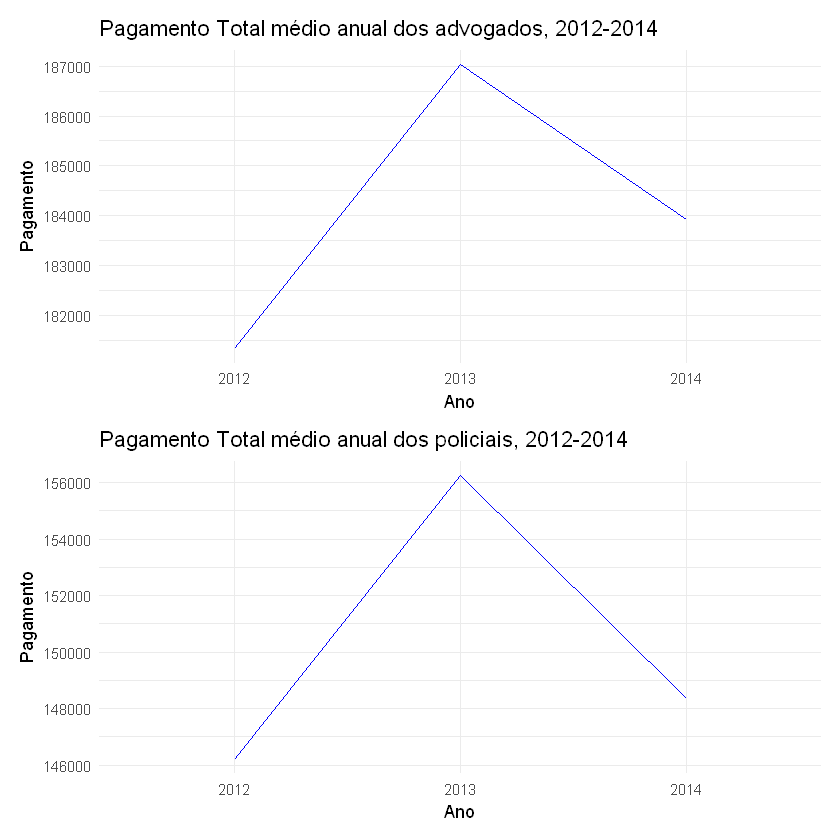

```r
# Objetivo 6: Usando a base DS2, represente graficamente os resultados do
# Pagamento Total médio anual para Advogados e Policiais nos anos de 2012 a 2014.
line1 =  ggplot(DS2 %>% filter(Cargo %in% "Advogado") ,  aes(Ano, PagamentoTotal, group=1)) +
  geom_line(color = 'blue') +
  labs(x = "Ano", y = "Pagamento",
       title = "Pagamento Total médio anual dos advogados, 2012-2014") + theme_minimal()

line2 = ggplot(DS2 %>% filter(Cargo %in% "Policial") ,  aes(Ano, PagamentoTotal, group=1)) +
  geom_line(color = 'blue') +
  labs(x = "Ano", y = "Pagamento",
       title = "Pagamento Total médio anual dos policiais, 2012-2014") + theme_minimal()

line1/line2
```

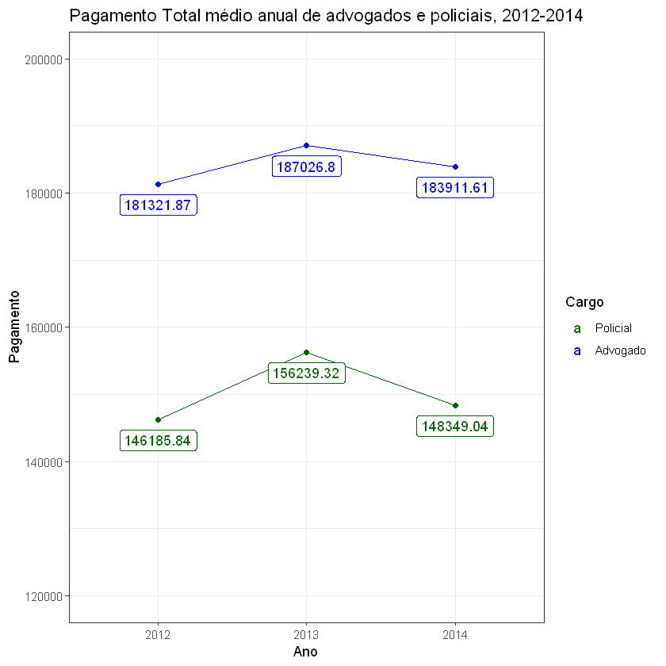

```r
# Alternativa:
objetivo6 = DS2 %>%
  filter(Cargo %in% c("Advogado","Policial") ) %>%
  ggplot(aes(Ano, PagamentoTotal, group=Cargo, color = Cargo))+
  geom_point() +
  geom_line() +
  scale_color_manual(values = c("Policial" = "darkgreen ", "Advogado" = "blue"))+
  geom_label(aes(label = PagamentoTotal), vjust = 1.5) +
  scale_y_continuous(limits = c(120000, 200000)) +
  labs(x = "Ano", y = "Pagamento", title = "Pagamento Total médio anual de advogados e policiais, 2012-2014")+
  theme_bw()

objetivo6
```

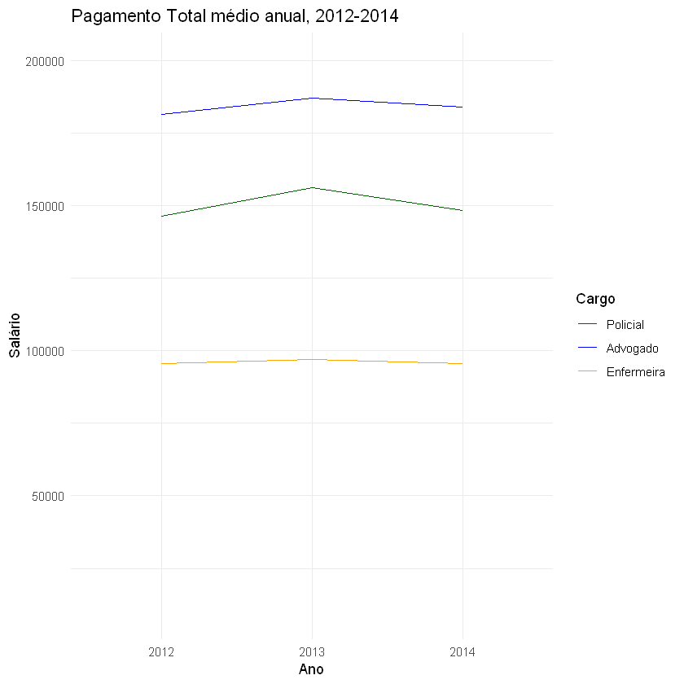

```r
# Objetivo 7: Usando a base DS2, represente graficamente os resultados do
# Pagamento Total médio anual para Advogados, Enfermeiras e Policiais nos
# anos de 2012 a 2014.

ggplot(data = DS2 %>% filter(Cargo %in% c("Policial", "Advogado", "Enfermeira")),
       aes(x = Ano, y = PagamentoTotal, group = Cargo, color = Cargo)) +
  geom_line() +
  labs(x = "Ano", y = "Salário", title = "Pagamento Total médio anual, 2012-2014") +
  scale_y_continuous(limits = c(10000, 200000)) +
  scale_color_manual(values = c("Policial" = "darkgreen ", "Advogado" = "blue",
                                "Enfermeira" = "orange"))+
  theme_minimal()
```

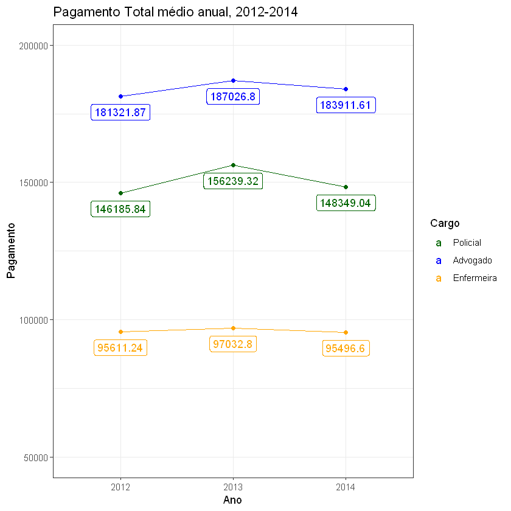

```r
# Alternativa:
objetivo7 = DS2 %>%
  filter(Cargo %in% c("Advogado","Policial", "Enfermeira") ) %>%
  ggplot(aes(Ano, PagamentoTotal, group=Cargo, color = Cargo))+
  geom_point() +
  geom_line() +
  scale_color_manual(values = c("Policial" = "darkgreen ", "Advogado" = "blue", "Enfermeira" = "orange"))+
  geom_label(aes(label = PagamentoTotal), vjust = 1.5) +
  scale_y_continuous(limits = c(50000, 200000)) +
  labs(x = "Ano", y = "Pagamento", title = "Pagamento Total médio anual, 2012-2014")+
  theme_bw()

objetivo7
```

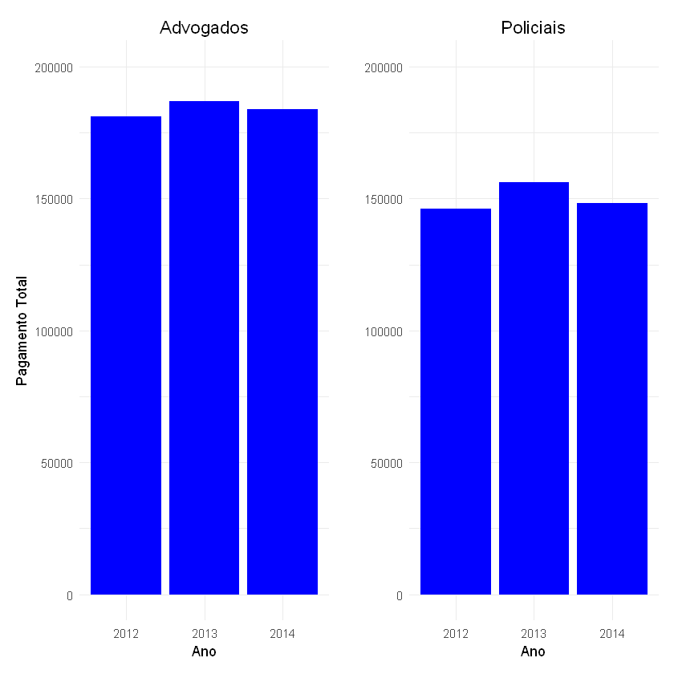

```r
# Objetivo 8: Usando a base DS2, apresente gráficos de colunas para a variável
# Pagamento Total dos Advogados e Policiais nos anos de 2012 a 2014.

bar1 = ggplot(data = DS2 %>% filter(Cargo %in% 'Advogado'),
              aes(x = Ano, y = PagamentoTotal, group = 1))+
  geom_bar(stat='identity',fill = 'blue')+ylim(0, 200000) + theme_minimal()+
  labs(x = "Ano", y = "Pagamento Total",
       title = "Advogados",)+
  theme(legend.position = "center", plot.title = element_text(hjust = 0.5, vjust = -0.2))

bar2 = ggplot(data = DS2 %>% filter(Cargo %in% 'Policial'),
              aes(x = Ano, y = PagamentoTotal, group = 1))+
  geom_bar(stat='identity',fill = 'blue')+ylim(0, 200000) + theme_minimal()+
  labs(x = "Ano", y = "",
       title = "Policiais",)+
  theme(legend.position = "center", plot.title = element_text(hjust = 0.5, vjust = -0.2))

bar1 + bar2
```

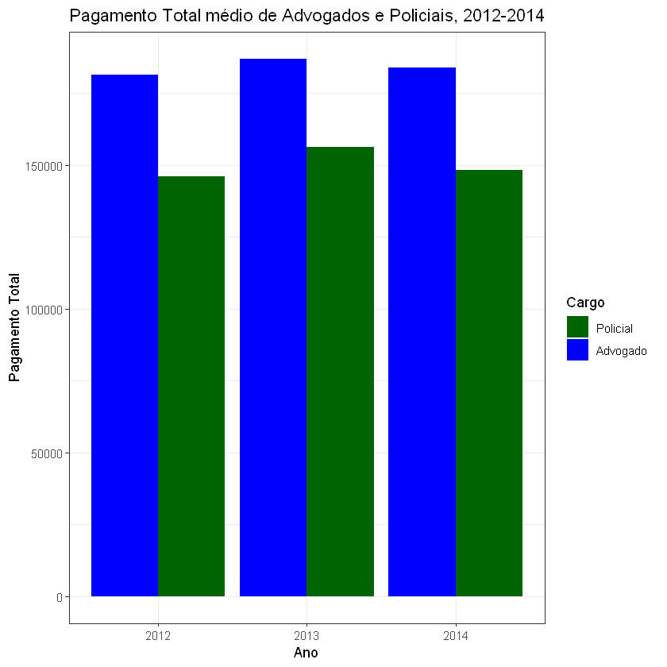

```r
#Alternativa
objetivo8 = DS2 %>%
  filter(Cargo %in% c("Advogado","Policial")) %>%
  ggplot(aes(x = Ano, y = PagamentoTotal, group = Cargo, fill = Cargo)) +
  geom_bar(stat='identity', position = "dodge") +
  scale_fill_manual(values = c("Policial" = "darkgreen ", "Advogado" = "blue")) +
  labs(x = "Ano", y = "Pagamento Total",
       title = "Pagamento Total médio de Advogados e Policiais, 2012-2014",)+
  theme_bw()

#OBS: não encontrei umma forma de ajustar a legenda interna com os valores
objetivo8
```

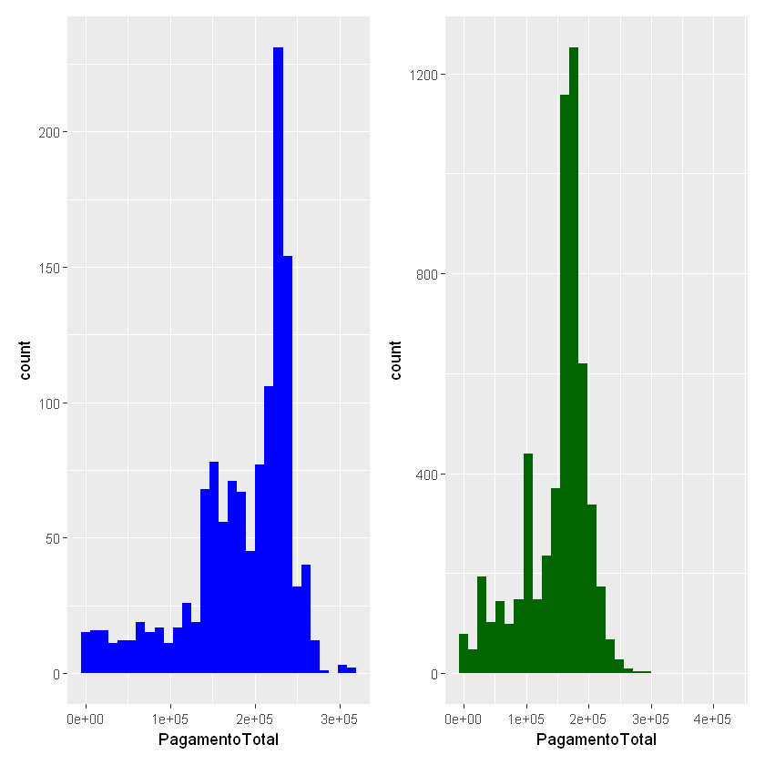

```r
#Objetivo 9: Usando a base DS1, apresente os histogramas para a variável Pagamento Total dos Advogados e Policiais.

objetivo9a = DS1 %>%
  filter(Cargo %in% "Advogado") %>%
  ggplot(aes(x = PagamentoTotal))+
  geom_histogram(position='identity', fill = "blue")

objetivo9b = DS1 %>%
  filter(Cargo %in% "Policial") %>%
  ggplot(aes(x = PagamentoTotal))+
  geom_histogram(position='identity', fill = "dark green")
objetivo9a + objetivo9b
#Trabalho em progresso...
```

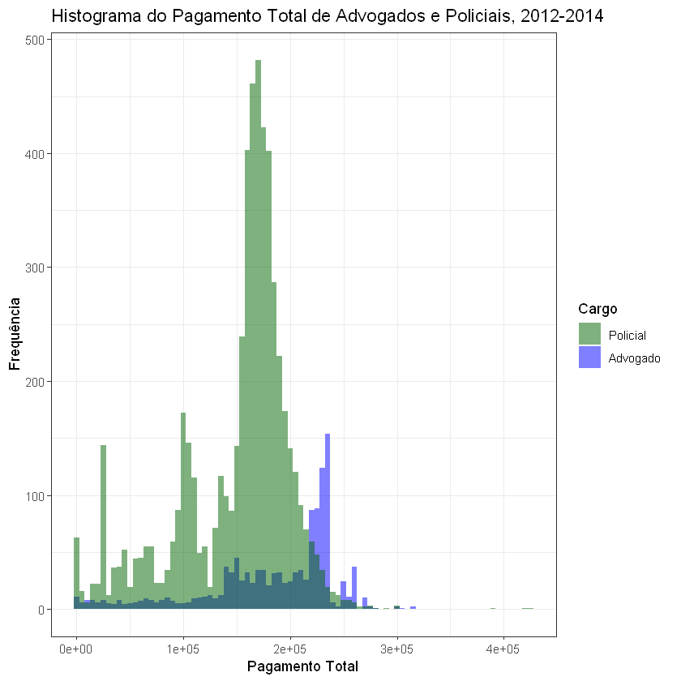

```r
#Alternativa
objetivo9c = DS1 %>%
  filter(Cargo %in% c("Advogado","Policial")) %>%
  ggplot(aes(x = PagamentoTotal, fill = Cargo))+
  geom_histogram( alpha=0.5, position = 'identity',binwidth = 5000)+
  scale_fill_manual(values = c("Policial" = "darkgreen ", "Advogado" = "blue")) +
  labs(x = "Pagamento Total", y = "Frequência",
       title = "Histograma do Pagamento Total de Advogados e Policiais, 2012-2014",)+
  theme_bw()
objetivo9c
```

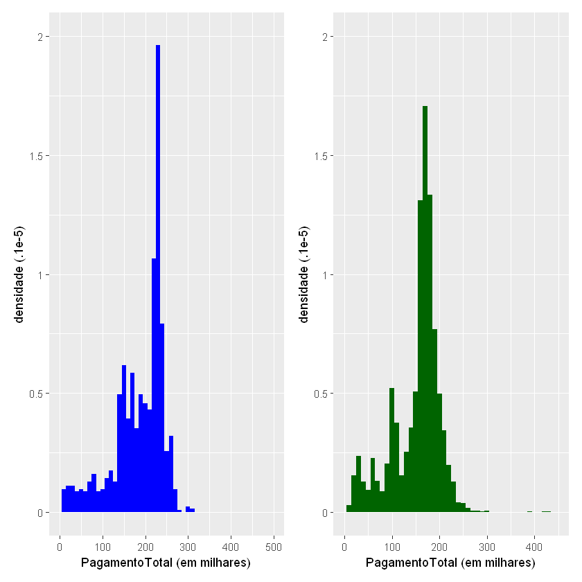

```r
# Alternativa 2
objetivo9a = DS1 %>%
  filter(Cargo %in% "Advogado") %>%
  ggplot(aes(x = PagamentoTotal))+
  geom_histogram(aes( y = ..density..), binwidth = 10000, fill = "blue") +
  labs(x = "PagamentoTotal (em milhares)", y = "densidade (.1e-5)") +
  scale_x_continuous(limits = c(0,500000),labels = seq(0,500,100)) +
  scale_y_continuous(limits = c(0,2e-05), labels = seq(0.0,2.0,0.5))


objetivo9b = DS1 %>%
  filter(Cargo %in% "Policial") %>%
  ggplot(aes(x = PagamentoTotal))+
  geom_histogram(aes( y = ..density..), binwidth = 10000, fill = "dark green") +
  labs(x = "PagamentoTotal (em milhares)", y = "densidade (.1e-5)") +
  scale_x_continuous(limits = c(0,450000), labels = seq(0,500,100)) +
  scale_y_continuous(limits = c(0,2e-05),  labels = seq(0.0,2.0,0.5))

objetivo9a + objetivo9b
```

```r
#Pergunta 1: Segundo os dados, é mais vantajoso seguir uma carreira de policial ou bombeiro?
P1 = DS1 %>%
  group_by(Cargo, Ano) %>%
  select(Cargo,Ano,PagamentoTotal) %>%
  summarise_all(mean) %>%
  mutate_if(is.numeric, round, digits=2)

P1 = P1 %>%
  filter(Cargo %in% c("Policial","Bombeiro")) %>%
  pivot_wider(names_from = Cargo, values_from = PagamentoTotal) %>%
  mutate(Diferença = Bombeiro-Policial)
P1
```

```
`mutate_if()` ignored the following grouping variables:
• Column `Cargo`
```

A tibble: 3 × 4

| Ano <chr> | Bombeiro <dbl> | Policial <dbl> | Diferença <dbl> |
| --- | --- | --- | --- |
| 2012 | 176812.7 | 146185.8 | 30626.83 |
| 2013 | 188247.1 | 156239.3 | 32007.82 |
| 2014 | 174109.7 | 148349.0 | 25760.64 |

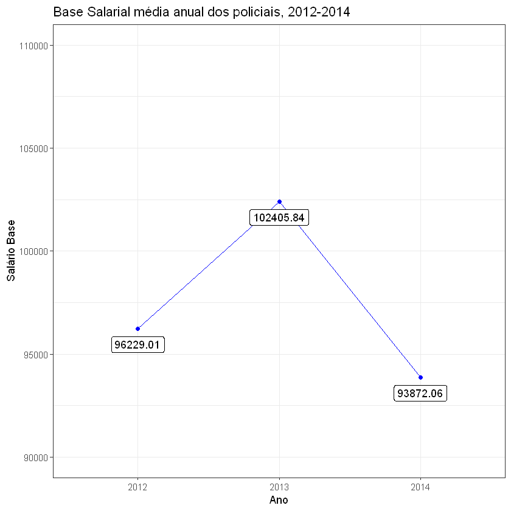

```r
#Pergunta 2: Como se comportou a base salarial dos policiais ao longo dos anos? Represente graficamente os resultados.
P2 = DS2 %>%
  filter(Cargo %in% "Policial") %>%
  ggplot(aes(Ano, SalarioBase, group=1)) +
  geom_point(color = 'blue')+
  geom_line(color = 'blue') +
  geom_label(aes(label = SalarioBase), vjust = 1.5) +
  scale_y_continuous(limits = c(90000, 110000)) +
  labs(x = "Ano", y = "Salário Base",
       title = "Base Salarial média anual dos policiais, 2012-2014") +
  theme_bw()
P2
```

```r
#Pergunta 3: Qual a média de pagamento total de todos os empregados a cada ano?
P3 = DS1 %>%
  group_by(Ano) %>%
  select(Ano,PagamentoTotal) %>%
  summarise_all(mean) %>%
  mutate_if(is.numeric, round, digits=2)

P3
```

A tibble: 3 × 2

| Ano <chr> | PagamentoTotal <dbl> |
| --- | --- |
| 2012 | 98203.91 |
| 2013 | 101115.38 |
| 2014 | 97869.83 |

```r
#Pergunta 4: Qual o top 5 de empregos mais comuns?
P4 = DS1 %>%
  count(Cargo, sort=T) %>%
  top_n(5)

P4
```

A data.frame: 5 × 2

| Cargo <chr> | n <int> |
| --- | --- |
| Enfermeira | 10115 |
| Operador de trânsito | 6975 |
| Escriturário | 6903 |
| Policial | 5665 |
| Bombeiro | 3262 |

A data.frame: 5 × 2

|  | Cargo <chr> | n <int> |
| --- | --- | --- |
| 1 | Enfermeira | 10115 |
| 2 | Operador de trânsito | 6975 |
| 3 | Escriturário | 6903 |
| 4 | Policial | 5665 |
| 5 | Bombeiro | 3262 |

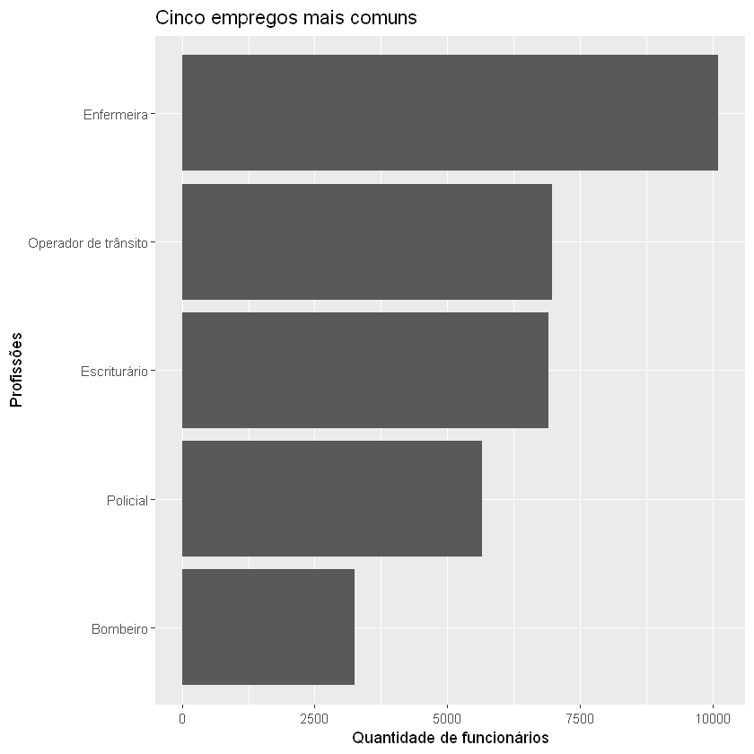

```r
#Pergunta 4:
  head(DS1 %>% count(Cargo) %>%arrange(desc(n)),5)

  ggplot(head(DS1 %>% count(Cargo) %>% arrange(desc(n)), 5), aes(x = reorder(Cargo, n), y = n)) +
    geom_bar(stat = "identity") +
    labs(x = "Profissões", y = "Quantidade de funcionários", title = "Cinco empregos mais comuns")+
    coord_flip() #inverte os eixos
```

A tibble: 10 × 2

| Cargo <chr> | total <dbl> |
| --- | --- |
| Enfermeira | 206362398 |
| Operador de trânsito | 192083606 |
| Policial | 178046890 |
| Escriturário | 145926575 |
| Gerente | 122836318 |
| Bombeiro | 119640058 |
| Engenheiro | 107060084 |
| Delegado | 90250171 |
| Advogado | 52954037 |
| Gestor de ativos | 51021308 |

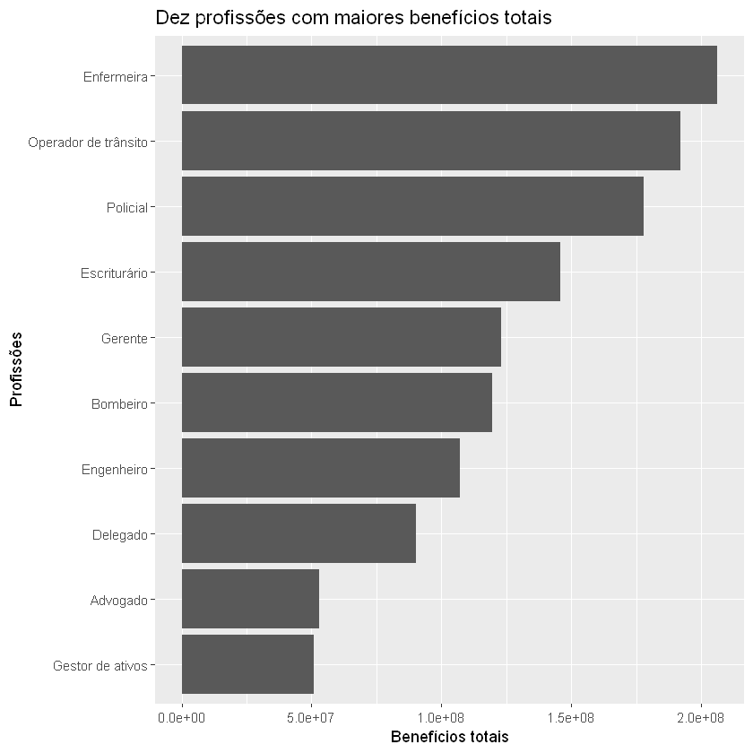

```r
#Pergunta 5: Quais os 10 cargos que mais receberam benefícios durante o período 2012-2014?
  head(DS1 %>% group_by(Cargo) %>%  summarise(total = sum(Beneficios)) %>% arrange(desc(total)),10)

  head(DS1 %>%
         group_by(Cargo) %>%
         summarise(total = sum(Beneficios)) %>%
         arrange(desc(total)),10) %>%
    ggplot(aes(x = reorder(Cargo, total), y = total)) +
    geom_bar(stat = "identity") +
    labs(x = "Profissões", y = "Benefícios totais", title = "Dez profissões com maiores benefícios totais") +
    coord_flip()
```

```r
# Pergunta 6: Quais os cargos dos 20 profissionais mais bem pagos em 2012?
P6 = DS1 %>%
  filter(Ano == '2012') %>%
  group_by(PagamentoTotal) %>%
  select(Cargo,PagamentoTotal,NomeFuncionario) %>%
  arrange(desc(PagamentoTotal)) %>%
  head(20)

P6
```

A grouped_df: 20 × 3

| Cargo <chr> | PagamentoTotal <dbl> | NomeFuncionario <chr> |
| --- | --- | --- |
| Policial | 391362.3 | Gregory Suhr |
| Bombeiro | 381643.1 | Frederick Binkley |
| Gerente | 359447.8 | Leda Rozier |
| Assistente médico | 339368.2 | Susan Currin |
| Bombeiro | 331307.0 | Scott Scholzen |
| Bombeiro | 321780.8 | Gregory Stangland |
| Médico | 317868.2 | Yifang Qian |
| Gerente | 312675.3 | Leanora Militello |
| Bombeiro | 308774.6 | Alvin Lau |
| Bombeiro | 302052.2 | Mike Breiling |
| Advogado | 301121.4 | George Gascon |
| Gerente | 299899.0 | Mivic Hirose |
| Bombeiro | 299721.2 | Martin Beltran |
| Assistente médico | 298045.7 | Jeffrey Myers |
| Bombeiro | 297922.1 | Douglas Spikes |
| Bombeiro | 294613.4 | Matthew Lane |
| Médico | 293457.3 | George Fouras |
| Gerente | 292201.1 | Julie Labonte |
| Médico | 287989.8 | Siu-Kwan Chow |
| Bombeiro | 286446.4 | Dwight Newton |